# Capstone_Task_2.1(group F3)

# b. How well those variables describe the price of a car

```python
corr_table=df1.drop(['Sales_ID'], axis=1)
corr_table.head()
```

|  | name | year | selling_price | km_driven | State or Province | City | fuel | seller_type | transmission | owner | mileage | engine | max_power | seats |
| --- | --- | --- | --- | --- | --- | --- | --- | --- | --- | --- | --- | --- | --- | --- |
| 0 | Maruti | 2014 | 450000 | 145500 | District of Columbia | Washington | Diesel | Individual | Manual | First Owner | 23.40 | 1248.0 | 74.00 | 5 |
| 1 | Skoda | 2014 | 370000 | 120000 | New York | New York City | Diesel | Individual | Manual | Second Owner | 21.14 | 1498.0 | 103.52 | 5 |
| 2 | Honda | 2006 | 158000 | 140000 | Illinois | Chicago | Petrol | Individual | Manual | Third Owner | 17.70 | 1497.0 | 78.00 | 5 |
| 3 | Hyundai | 2010 | 225000 | 127000 | Illinois | Chicago | Diesel | Individual | Manual | First Owner | 23.00 | 1396.0 | 90.00 | 5 |
| 4 | Maruti | 2007 | 130000 | 120000 | New York | New York City | Petrol | Individual | Manual | First Owner | 16.10 | 1298.0 | 88.20 | 5 |

```python
corr_table = corr_table.select_dtypes(include=['float64', 'int64','object'])
cor = corr_table.corr()
cor
```

|  | year | selling_price | km_driven | mileage | engine | max_power | seats |
| --- | --- | --- | --- | --- | --- | --- | --- |
| year | 1.000000 | 0.412302 | -0.428548 | 0.328544 | 0.018263 | 0.226598 | -0.007923 |
| selling_price | 0.412302 | 1.000000 | -0.222158 | -0.126280 | 0.455682 | 0.749674 | 0.041617 |
| km_driven | -0.428548 | -0.222158 | 1.000000 | -0.172980 | 0.206031 | -0.038159 | 0.227259 |
| mileage | 0.328544 | -0.126280 | -0.172980 | 1.000000 | -0.576408 | -0.374621 | -0.451700 |
| engine | 0.018263 | 0.455682 | 0.206031 | -0.576408 | 1.000000 | 0.703975 | 0.611103 |
| max_power | 0.226598 | 0.749674 | -0.038159 | -0.374621 | 0.703975 | 1.000000 | 0.191999 |
| seats | -0.007923 | 0.041617 | 0.227259 | -0.451700 | 0.611103 | 0.191999 | 1.000000 |

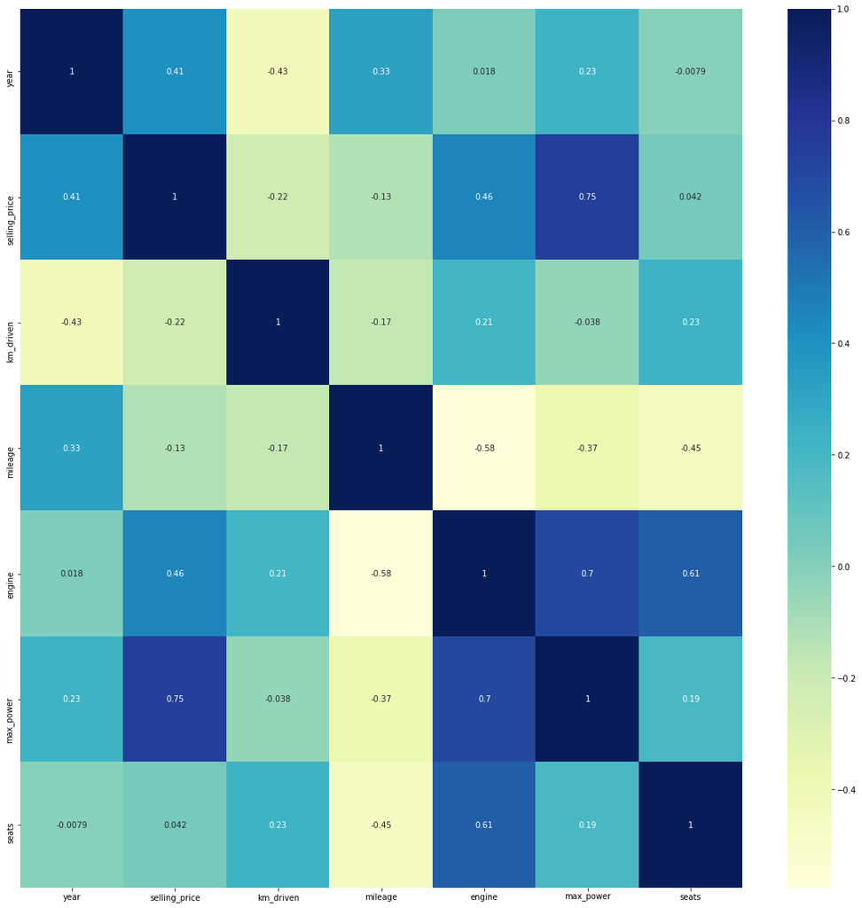

```python
plt.figure(figsize=(20,20))

# heatmap
sns.heatmap(cor, cmap="YlGnBu", annot=True)
plt.show()
```

2.1 b) For describing the price of a car we can use correlation function between target column and numerical feature coulmn here if value is>0.7. Generally, a value of r greater than 0.7 is considered a strong correlation. Anything between 0.5 and 0.7 is a moderate correlation, and anything less than 0.4 is considered a weak or no correlation. In our analysis max_power is highly correlated to selling_price whereas Km_driven and mileage negatively correlated.

# Merging of Datasets

```python
df2 = pd.read_csv("C:/Users/chittreddy/Documents/sales_Status_p3.csv")
df2
```

|  | Sales_ID | sold |
| --- | --- | --- |
| 0 | 1 | Y |
| 1 | 2 | Y |
| 2 | 3 | Y |
| 3 | 4 | Y |
| 4 | 5 | Y |
| ... | ... | ... |
| 7901 | 8124 | N |
| 7902 | 8125 | N |
| 7903 | 8126 | N |
| 7904 | 8127 | N |
| 7905 | 8128 | N |

7906 rows × 2 columns

```python
df3 = pd.read_csv("C:/Users/chittreddy/Documents/State_region_mapping_p3.csv")
df3
```

|  | Region | State or Province |
| --- | --- | --- |
| 0 | Central | Illinois |
| 1 | Central | Indiana |
| 2 | Central | Iowa |
| 3 | Central | Kansas |
| 4 | Central | Michigan |
| 5 | Central | Minnesota |
| 6 | Central | Missouri |
| 7 | Central | Nebraska |
| 8 | Central | North Dakota |
| 9 | Central | Oklahoma |
| 10 | Central | South Dakota |
| 11 | Central | Texas |
| 12 | Central | Wisconsin |
| 13 | East | Connecticut |
| 14 | East | Delaware |
| 15 | East | District of Columbia |
| 16 | East | Maine |
| 17 | East | Maryland |
| 18 | East | Massachusetts |
| 19 | East | New Hampshire |
| 20 | East | New Jersey |
| 21 | East | New York |
| 22 | East | Ohio |
| 23 | East | Pennsylvania |
| 24 | East | Rhode Island |
| 25 | East | Vermont |
| 26 | East | West Virginia |
| 27 | South | Alabama |
| 28 | South | Arkansas |
| 29 | South | Florida |
| 30 | South | Georgia |
| 31 | South | Kentucky |
| 32 | South | Louisiana |
| 33 | South | Mississippi |
| 34 | South | North Carolina |
| 35 | South | South Carolina |
| 36 | South | Tennessee |
| 37 | South | Virginia |
| 38 | West | Arizona |
| 39 | West | California |
| 40 | West | Colorado |
| 41 | West | Idaho |
| 42 | West | Montana |
| 43 | West | Nevada |
| 44 | West | New Mexico |
| 45 | West | Oregon |
| 46 | West | Utah |
| 47 | West | Washington |
| 48 | West | Wyoming |

```python
df4=pd.merge(df1,df2,how="left",on="Sales_ID")
```

```python
df=pd.merge(df4,df3,how="left",on="State or Province")
df
```

|  | Sales_ID | name | year | selling_price | km_driven | State or Province | City | fuel | seller_type | transmission | owner | mileage | engine | max_power | seats | sold | Region |
| --- | --- | --- | --- | --- | --- | --- | --- | --- | --- | --- | --- | --- | --- | --- | --- | --- | --- |
| 0 | 1 | Maruti | 2014 | 450000 | 145500 | District of Columbia | Washington | Diesel | Individual | Manual | First Owner | 23.40 | 1248.0 | 74.00 | 5 | Y | East |
| 1 | 2 | Skoda | 2014 | 370000 | 120000 | New York | New York City | Diesel | Individual | Manual | Second Owner | 21.14 | 1498.0 | 103.52 | 5 | Y | East |
| 2 | 3 | Honda | 2006 | 158000 | 140000 | Illinois | Chicago | Petrol | Individual | Manual | Third Owner | 17.70 | 1497.0 | 78.00 | 5 | Y | Central |
| 3 | 4 | Hyundai | 2010 | 225000 | 127000 | Illinois | Chicago | Diesel | Individual | Manual | First Owner | 23.00 | 1396.0 | 90.00 | 5 | Y | Central |
| 4 | 5 | Maruti | 2007 | 130000 | 120000 | New York | New York City | Petrol | Individual | Manual | First Owner | 16.10 | 1298.0 | 88.20 | 5 | Y | East |
| ... | ... | ... | ... | ... | ... | ... | ... | ... | ... | ... | ... | ... | ... | ... | ... | ... | ... |
| 7901 | 8124 | Hyundai | 2013 | 320000 | 110000 | Texas | Plano | Petrol | Individual | Manual | First Owner | 18.50 | 1197.0 | 82.85 | 5 | N | Central |
| 7902 | 8125 | Hyundai | 2007 | 135000 | 119000 | Texas | Port Arthur | Diesel | Individual | Manual | Fourth & Above Owner | 16.80 | 1493.0 | 110.00 | 5 | N | Central |
| 7903 | 8126 | Maruti | 2009 | 382000 | 120000 | Texas | Port Arthur | Diesel | Individual | Manual | First Owner | 19.30 | 1248.0 | 73.90 | 5 | N | Central |
| 7904 | 8127 | Tata | 2013 | 290000 | 25000 | Massachusetts | Lunenburg | Diesel | Individual | Manual | First Owner | 23.57 | 1396.0 | 70.00 | 5 | N | East |
| 7905 | 8128 | Tata | 2013 | 290000 | 25000 | Maine | Augusta | Diesel | Individual | Manual | First Owner | 23.57 | 1396.0 | 70.00 | 5 | N | East |

7906 rows × 17 columns

# c. Which brands are selling most?

```python
A=df[df["sold"]=="Y"]
```

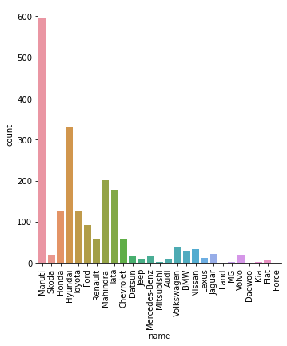

```python
sns.catplot(x="name",data=A,kind="count")
plt.xticks(rotation=90)
plt.show()
```

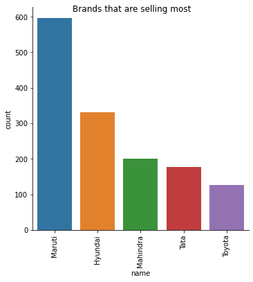

```python
a=sns.catplot(x="name",data=A,kind="count",order=A["name"].value_counts().head().index)
a.fig.suptitle("Brands that are selling most")
plt.xticks(rotation=90)
plt.show()
```

So Maruti, Hyundai, Mahindra, Tata, Toyota are top five selling brands

# d. Are there specific locations selling more?

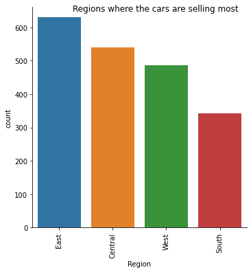

```python
a=sns.catplot(x="Region",data=A,kind="count",order=A["Region"].value_counts().index)
a.fig.suptitle("Regions where the cars are selling most",x=0.6)
plt.xticks(rotation=90)
plt.show()
```

So the highest number of cars are sold in East region

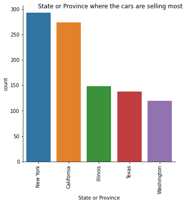

```python
a=sns.catplot(x="State or Province",data=A,kind="count",order=A["State or Province"].value_counts().head().index)
a.fig.suptitle("State or Province where the cars are selling most",x=0.6)
plt.xticks(rotation=90)
plt.show()
```

So the highest number of cars are sold in New York State

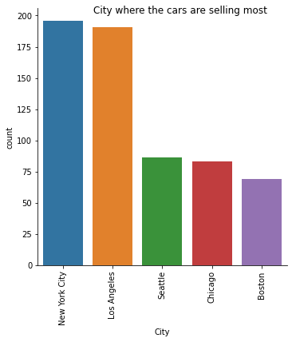

```python
a=sns.catplot(x="City",data=A,kind="count",order=A["City"].value_counts().head().index)
a.fig.suptitle("City where the cars are selling most",x=0.6)
plt.xticks(rotation=90)
plt.show()
```

So the highest number of cars are sold in New York City